# HW4

#### مدل تا حدی ناهمسانی واریانس دارد و با افزایش متغیر هدف میزان خطا ها نیز افزایش می یابد

در ادامه مدل بهتر بدست آمده است.

```python
X_train_tv_2 = pd.DataFrame({'tv2': X_train_tv['tv'] ** 2})
X_train_tv_2 = pd.concat([X_train_tv, X_train_tv_2], axis=1)
X_train_tv_2
```

|  | const | tv | tv2 |
| --- | --- | --- | --- |
| 24 | 1.0 | 62.3 | 3881.29 |
| 150 | 1.0 | 280.7 | 78792.49 |
| 114 | 1.0 | 78.2 | 6115.24 |
| 33 | 1.0 | 265.6 | 70543.36 |
| 23 | 1.0 | 228.3 | 52120.89 |
| ... | ... | ... | ... |
| 17 | 1.0 | 281.4 | 79185.96 |
| 98 | 1.0 | 289.7 | 83926.09 |
| 66 | 1.0 | 31.5 | 992.25 |
| 126 | 1.0 | 7.8 | 60.84 |
| 109 | 1.0 | 255.4 | 65229.16 |

160 rows × 3 columns

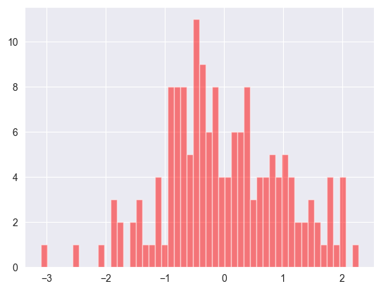

```
                            OLS Regression Results
==============================================================================
Dep. Variable:                      y   R-squared:                       0.627
Model:                            OLS   Adj. R-squared:                  0.623
Method:                 Least Squares   F-statistic:                     132.2
Date:                Tue, 09 Apr 2024   Prob (F-statistic):           2.19e-34
Time:                        23:50:55   Log-Likelihood:                -148.05
No. Observations:                 160   AIC:                             302.1
Df Residuals:                     157   BIC:                             311.3
Df Model:                           2
Covariance Type:            nonrobust
==============================================================================
                 coef    std err          t      P>|t|      [0.025      0.975]
------------------------------------------------------------------------------
const         -1.6758      0.145    -11.578      0.000      -1.962      -1.390
tv             0.0154      0.002      6.783      0.000       0.011       0.020
tv2        -2.158e-05   7.52e-06     -2.870      0.005   -3.64e-05   -6.73e-06
==============================================================================
Omnibus:                        4.817   Durbin-Watson:                   1.754
Prob(Omnibus):                  0.090   Jarque-Bera (JB):                2.897
Skew:                          -0.110   Prob(JB):                        0.235
Kurtosis:                       2.378   Cond. No.                     1.18e+05
==============================================================================

Notes:
[1] Standard Errors assume that the covariance matrix of the errors is correctly specified.
[2] The condition number is large, 1.18e+05. This might indicate that there are
strong multicollinearity or other numerical problems.
```

```python
#Linear regression - model based on tv polynomial

#Box-Cox transformation
from sklearn.preprocessing import PowerTransformer

boxcox = PowerTransformer(method='box-cox')
boxcox.fit(y_train.values.reshape(-1, 1))

trans_y_train = boxcox.fit_transform(y_train.values.reshape(-1, 1))
plt.hist(trans_y_train, color = 'red', alpha = 0.5, bins = 50)
plt.show()

model_tv_polynomial = sm.OLS(trans_y_train, X_train_tv_2).fit()
print(model_tv_polynomial.summary())
```

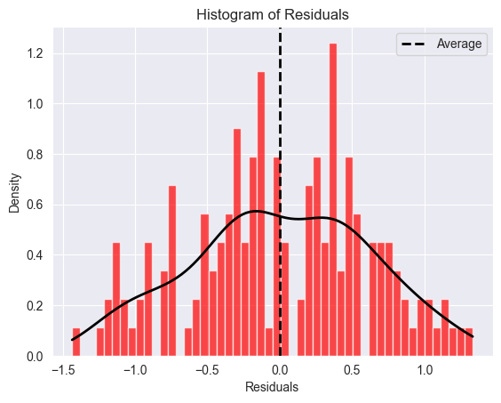

```python
#Histogram of residuals - model tv polynomial
hist_residuals(model_tv_polynomial)
```

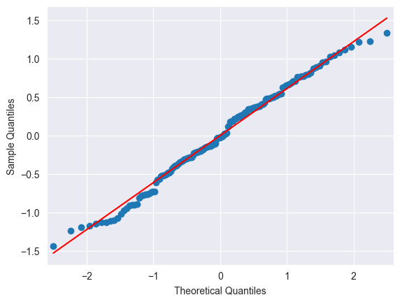

```python
#QQ-plot - model tv polynomial
sm.qqplot(model_tv_polynomial.resid, line='s')
plt.show()
```

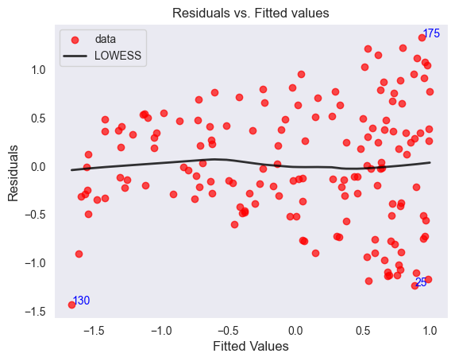

```python
#Scatter plot of residuals vs. fitted values - model tv polynomial
residuals_fittedvalues_plot(model_tv_polynomial)
```

```python
#Check Cook's ditance - model_tv_polynomial
influencer_detector(model_tv_polynomial)
```

```
(array([], dtype=int64),)
```

اشکال مدل تا حد زیادی درست شده است.

# C

```python
model_All = sm.OLS(y_train, X_train).fit()
print(model_All.summary())
```

```
                            OLS Regression Results
==============================================================================
Dep. Variable:                  sales   R-squared:                       0.887
Model:                            OLS   Adj. R-squared:                  0.885
Method:                 Least Squares   F-statistic:                     409.8
Date:                Tue, 09 Apr 2024   Prob (F-statistic):           9.89e-74
Time:                        23:50:55   Log-Likelihood:                -313.24
No. Observations:                 160   AIC:                             634.5
Df Residuals:                     156   BIC:                             646.8
Df Model:                           3
Covariance Type:            nonrobust
==============================================================================
                 coef    std err          t      P>|t|      [0.025      0.975]
------------------------------------------------------------------------------
const          2.9242      0.365      8.018      0.000       2.204       3.645
tv             0.0456      0.002     28.437      0.000       0.042       0.049
radio          0.1865      0.010     18.700      0.000       0.167       0.206
newspaper     -0.0006      0.007     -0.094      0.925      -0.014       0.013
==============================================================================
Omnibus:                       50.642   Durbin-Watson:                   2.294
Prob(Omnibus):                  0.000   Jarque-Bera (JB):              123.512
Skew:                          -1.335   Prob(JB):                     1.51e-27
Kurtosis:                       6.376   Cond. No.                         469.
==============================================================================

Notes:
[1] Standard Errors assume that the covariance matrix of the errors is correctly specified.
```

model assumptions:

1- linearity between dependant and independant variables.

3- normal distribution of error (will check later).

4- Homoscedasticity (The spread of residuals should be uniform across the range of predictions).

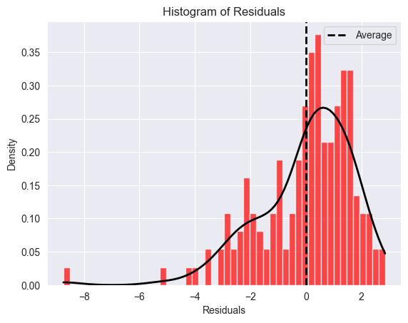

```python
#Histogram of residuals - model 1
hist_residuals(model_All)
```

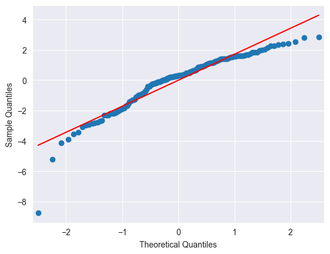

```python
#QQ-plot - model 1
sm.qqplot(model_All.resid, line='s')
plt.show()
```

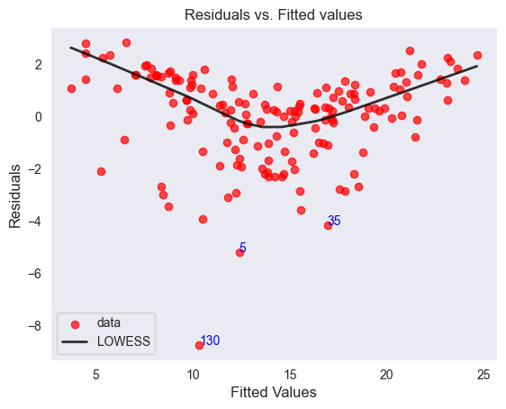

```python
#Scatter plot of residuals vs. fitted values - model 1
residuals_fittedvalues_plot(model_All)
```

```python
#Check Cook's ditance - model 1
influencer_detector(model_All)
```

```
(array([], dtype=int64),)
```

```python
train.iloc[[5, 35, 130], :]
```

|  | no | tv | radio | newspaper | sales |
| --- | --- | --- | --- | --- | --- |
| 171 | 172 | 164.5 | 20.9 | 47.4 | 14.5 |
| 44 | 45 | 25.1 | 25.7 | 43.3 | 8.5 |
| 173 | 174 | 168.4 | 7.1 | 12.8 | 11.7 |

```python
#Function to check multicollinearity
from statsmodels.stats.outliers_influence import variance_inflation_factor

def calc_vif(X):
    #Calculating VIF
    vif = pd.DataFrame()
    vif["variables"] = X.columns
    vif["VIF"] = [variance_inflation_factor(X, i) for i in range(X.shape[1])]
    return(vif)
```

```python
#Check multicollinearity for numeric variables
calc_vif(X_train[['tv', 'radio', 'newspaper']])
#Note: If VIF > 10 then multicollinearity is high
```

|  | variables | VIF |
| --- | --- | --- |
| 0 | tv | 2.372829 |
| 1 | radio | 3.302786 |
| 2 | newspaper | 3.057785 |

##### Box-Cox Transformation

```python
#Linear regression - model_All_transformed
model_All_transformed = sm.OLS(trans_y_train, X_train).fit()
print(model_All_transformed.summary())
```

```
                            OLS Regression Results
==============================================================================
Dep. Variable:                      y   R-squared:                       0.874
Model:                            OLS   Adj. R-squared:                  0.871
Method:                 Least Squares   F-statistic:                     360.1
Date:                Tue, 09 Apr 2024   Prob (F-statistic):           7.11e-70
Time:                        23:50:56   Log-Likelihood:                -61.434
No. Observations:                 160   AIC:                             130.9
Df Residuals:                     156   BIC:                             143.2
Df Model:                           3
Covariance Type:            nonrobust
==============================================================================
                 coef    std err          t      P>|t|      [0.025      0.975]
------------------------------------------------------------------------------
const         -2.1658      0.076    -28.651      0.000      -2.315      -2.016
tv             0.0090      0.000     27.228      0.000       0.008       0.010
radio          0.0345      0.002     16.701      0.000       0.030       0.039
newspaper   9.485e-05      0.001      0.068      0.946      -0.003       0.003
==============================================================================
Omnibus:                      104.499   Durbin-Watson:                   2.306
Prob(Omnibus):                  0.000   Jarque-Bera (JB):              817.878
Skew:                          -2.312   Prob(JB):                    2.51e-178
Kurtosis:                      13.065   Cond. No.                         469.
==============================================================================

Notes:
[1] Standard Errors assume that the covariance matrix of the errors is correctly specified.
```

```python
# مقدار P-value برای Newspaper بزرگتر از 0.05 است اما چون در قسمت D حذف می شود اینجا کاری نمی کنیم.
```

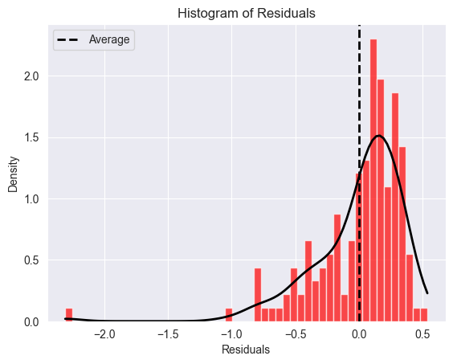

```python
#Histogram of residuals - model_All_transformed
hist_residuals(model_All_transformed)
```

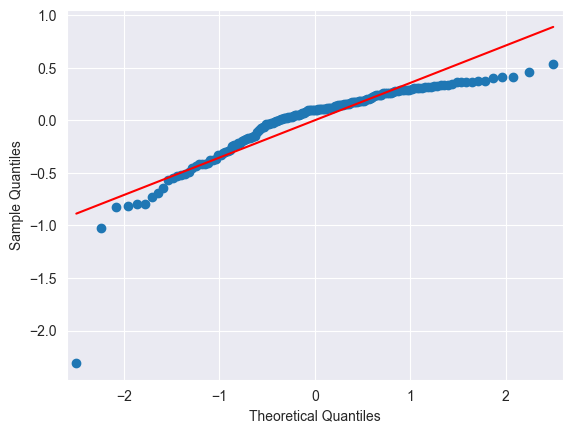

```python
#QQ-plot - model_All_transformed
sm.qqplot(model_All_transformed.resid, line = 's')
plt.show()
```

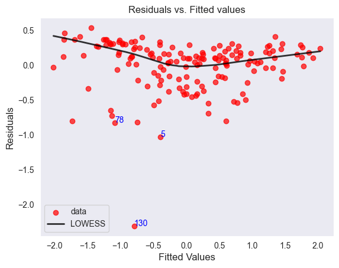

```python
#Scatter plot of residuals vs. fitted values - model_All_transformed
residuals_fittedvalues_plot(model_All_transformed)
```

```python
#Check Cook's ditance - model_All_transformed
influencer_detector(model_All_transformed)
```

```
(array([], dtype=int64),)
```

##### در دو نمودار بالا رکورد با ایندکس 130 اثر زیادی در مدل می گذارد برای همین این رکورد را حذف می کنیم

```python
X_train.drop(index = [130], inplace = True)
y_train.drop(index = [130], inplace = True)
trans_y_train = PowerTransformer(method = 'box-cox').fit_transform(y_train.values.reshape(-1, 1))
```

```python
#Linear regression - model_All_transformed2
model_All_transformed2 = sm.OLS(trans_y_train, X_train).fit()
print(model_All_transformed2.summary())
```

```
                            OLS Regression Results
==============================================================================
Dep. Variable:                      y   R-squared:                       0.898
Model:                            OLS   Adj. R-squared:                  0.896
Method:                 Least Squares   F-statistic:                     454.1
Date:                Tue, 09 Apr 2024   Prob (F-statistic):           1.56e-76
Time:                        23:50:57   Log-Likelihood:                -44.251
No. Observations:                 159   AIC:                             96.50
Df Residuals:                     155   BIC:                             108.8
Df Model:                           3
Covariance Type:            nonrobust
==============================================================================
                 coef    std err          t      P>|t|      [0.025      0.975]
------------------------------------------------------------------------------
const         -2.1841      0.068    -31.930      0.000      -2.319      -2.049
tv             0.0090      0.000     29.958      0.000       0.008       0.010
radio          0.0366      0.002     19.511      0.000       0.033       0.040
newspaper     -0.0010      0.001     -0.813      0.418      -0.004       0.001
==============================================================================
Omnibus:                       44.758   Durbin-Watson:                   2.320
Prob(Omnibus):                  0.000   Jarque-Bera (JB):               77.419
Skew:                          -1.388   Prob(JB):                     1.54e-17
Kurtosis:                       4.995   Cond. No.                         472.
==============================================================================

Notes:
[1] Standard Errors assume that the covariance matrix of the errors is correctly specified.
```

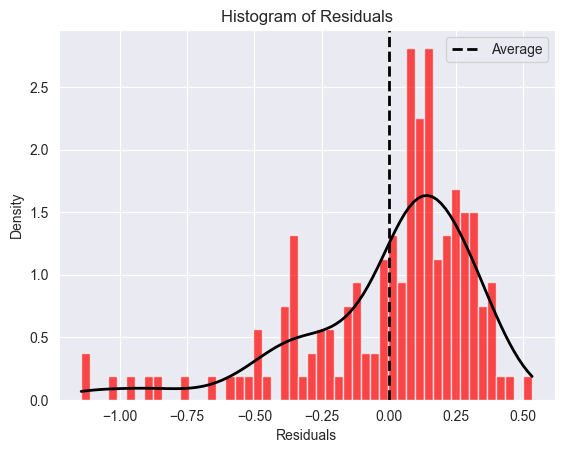

```python
#Histogram of residuals - model_All_transformed2
hist_residuals(model_All_transformed2)
```

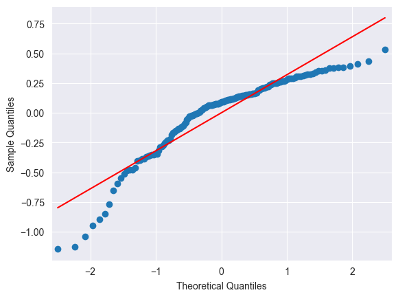

```python
#QQ-plot - model_All_transformed2
sm.qqplot(model_All_transformed2.resid, line = 's')
plt.show()
```

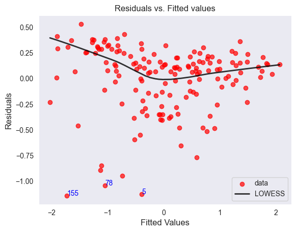

```python
#Scatter plot of residuals vs. fitted values - model_All_transformed2
residuals_fittedvalues_plot(model_All_transformed2)
```

```python
#Check Cook's ditance - model_All_transformed2
influencer_detector(model_All_transformed2)
```

```
(array([], dtype=int64),)
```

## D

including Interaction Effect

```python
from sklearn.preprocessing import PolynomialFeatures

poly_features = PolynomialFeatures(interaction_only=True)
X_train_interaction = pd.DataFrame(poly_features.fit_transform(X_train[['tv', 'radio', 'newspaper']]),
                                   columns=['const', 'tv', 'radio', 'newspaper', 'tv_radio', 'tv_newspaper',
                                            'radio_newspaper'], index=X_train.index)
```

```python
model_with_interaction = sm.OLS(y_train, X_train_interaction).fit()
print(model_with_interaction.summary())
```

```
                            OLS Regression Results
==============================================================================
Dep. Variable:                  sales   R-squared:                       0.973
Model:                            OLS   Adj. R-squared:                  0.972
Method:                 Least Squares   F-statistic:                     905.1
Date:                Tue, 09 Apr 2024   Prob (F-statistic):          3.27e-116
Time:                        23:50:57   Log-Likelihood:                -195.87
No. Observations:                 159   AIC:                             405.7
Df Residuals:                     152   BIC:                             427.2
Df Model:                           6
Covariance Type:            nonrobust
===================================================================================
                      coef    std err          t      P>|t|      [0.025      0.975]
-----------------------------------------------------------------------------------
const               6.5685      0.322     20.399      0.000       5.932       7.205
tv                  0.0194      0.002     12.131      0.000       0.016       0.023
radio               0.0408      0.012      3.481      0.001       0.018       0.064
newspaper           0.0097      0.010      0.935      0.351      -0.011       0.030
tv_radio            0.0011   5.89e-05     18.043      0.000       0.001       0.001
tv_newspaper    -2.989e-05   3.59e-05     -0.832      0.407      -0.000    4.11e-05
radio_newspaper    -0.0002      0.000     -0.882      0.379      -0.001       0.000
==============================================================================
Omnibus:                       61.748   Durbin-Watson:                   2.297
Prob(Omnibus):                  0.000   Jarque-Bera (JB):              181.270
Skew:                          -1.564   Prob(JB):                     4.34e-40
Kurtosis:                       7.193   Cond. No.                     3.80e+04
==============================================================================

Notes:
[1] Standard Errors assume that the covariance matrix of the errors is correctly specified.
[2] The condition number is large, 3.8e+04. This might indicate that there are
strong multicollinearity or other numerical problems.
```

#### adj R2 = 0.972

```python
X_train_interaction_2 = X_train_interaction[['const', 'tv', 'radio', 'newspaper', 'tv_radio', 'tv_newspaper']]
model_with_interaction_2 = sm.OLS(y_train, X_train_interaction_2).fit()
print(model_with_interaction_2.summary())
```

```
                            OLS Regression Results
==============================================================================
Dep. Variable:                  sales   R-squared:                       0.973
Model:                            OLS   Adj. R-squared:                  0.972
Method:                 Least Squares   F-statistic:                     1088.
Date:                Tue, 09 Apr 2024   Prob (F-statistic):          1.39e-117
Time:                        23:50:57   Log-Likelihood:                -196.28
No. Observations:                 159   AIC:                             404.6
Df Residuals:                     153   BIC:                             423.0
Df Model:                           5
Covariance Type:            nonrobust
================================================================================
                   coef    std err          t      P>|t|      [0.025      0.975]
--------------------------------------------------------------------------------
const            6.7253      0.268     25.067      0.000       6.195       7.255
tv               0.0194      0.002     12.151      0.000       0.016       0.023
radio            0.0356      0.010      3.523      0.001       0.016       0.056
newspaper        0.0024      0.006      0.385      0.701      -0.010       0.015
tv_radio         0.0011   5.82e-05     18.125      0.000       0.001       0.001
tv_newspaper -2.257e-05   3.49e-05     -0.646      0.519   -9.15e-05    4.64e-05
==============================================================================
Omnibus:                       63.854   Durbin-Watson:                   2.294
Prob(Omnibus):                  0.000   Jarque-Bera (JB):              193.199
Skew:                          -1.609   Prob(JB):                     1.12e-42
Kurtosis:                       7.337   Cond. No.                     3.14e+04
==============================================================================

Notes:
[1] Standard Errors assume that the covariance matrix of the errors is correctly specified.
[2] The condition number is large, 3.14e+04. This might indicate that there are
strong multicollinearity or other numerical problems.
```

```python
X_train_interaction_3 = X_train_interaction[['const', 'tv', 'radio', 'tv_radio', 'tv_newspaper']]
model_with_interaction_3 = sm.OLS(y_train, X_train_interaction_3).fit()
print(model_with_interaction_3.summary())
```

```
                            OLS Regression Results
==============================================================================
Dep. Variable:                  sales   R-squared:                       0.973
Model:                            OLS   Adj. R-squared:                  0.972
Method:                 Least Squares   F-statistic:                     1367.
Date:                Tue, 09 Apr 2024   Prob (F-statistic):          3.79e-119
Time:                        23:50:57   Log-Likelihood:                -196.35
No. Observations:                 159   AIC:                             402.7
Df Residuals:                     154   BIC:                             418.0
Df Model:                           4
Covariance Type:            nonrobust
================================================================================
                   coef    std err          t      P>|t|      [0.025      0.975]
--------------------------------------------------------------------------------
const            6.7588      0.253     26.706      0.000       6.259       7.259
tv               0.0193      0.002     12.495      0.000       0.016       0.022
radio            0.0374      0.009      4.186      0.000       0.020       0.055
tv_radio         0.0010   5.34e-05     19.572      0.000       0.001       0.001
tv_newspaper -1.111e-05   1.82e-05     -0.609      0.543   -4.71e-05    2.49e-05
==============================================================================
Omnibus:                       65.493   Durbin-Watson:                   2.290
Prob(Omnibus):                  0.000   Jarque-Bera (JB):              206.342
Skew:                          -1.635   Prob(JB):                     1.56e-45
Kurtosis:                       7.523   Cond. No.                     2.97e+04
==============================================================================

Notes:
[1] Standard Errors assume that the covariance matrix of the errors is correctly specified.
[2] The condition number is large, 2.97e+04. This might indicate that there are
strong multicollinearity or other numerical problems.
```

```python
X_train_interaction_4 = X_train_interaction[['const', 'tv', 'radio', 'tv_radio']]
model_with_interaction_4 = sm.OLS(y_train, X_train_interaction_4).fit()
print(model_with_interaction_4.summary())
```

```
                            OLS Regression Results
==============================================================================
Dep. Variable:                  sales   R-squared:                       0.973
Model:                            OLS   Adj. R-squared:                  0.972
Method:                 Least Squares   F-statistic:                     1830.
Date:                Tue, 09 Apr 2024   Prob (F-statistic):          9.81e-121
Time:                        23:50:57   Log-Likelihood:                -196.54
No. Observations:                 159   AIC:                             401.1
Df Residuals:                     155   BIC:                             413.4
Df Model:                           3
Covariance Type:            nonrobust
==============================================================================
                 coef    std err          t      P>|t|      [0.025      0.975]
------------------------------------------------------------------------------
const          6.7603      0.253     26.767      0.000       6.261       7.259
tv             0.0190      0.001     12.701      0.000       0.016       0.022
radio          0.0374      0.009      4.199      0.000       0.020       0.055
tv_radio       0.0010   5.23e-05     19.875      0.000       0.001       0.001
==============================================================================
Omnibus:                       65.419   Durbin-Watson:                   2.280
Prob(Omnibus):                  0.000   Jarque-Bera (JB):              205.060
Skew:                          -1.635   Prob(JB):                     2.96e-45
Kurtosis:                       7.501   Cond. No.                     1.83e+04
==============================================================================

Notes:
[1] Standard Errors assume that the covariance matrix of the errors is correctly specified.
[2] The condition number is large, 1.83e+04. This might indicate that there are
strong multicollinearity or other numerical problems.
```

```python
# در مدل بالا R2 adj تغییری نکرده است اما توانسته ایم با متغیر کمتری به این دقت برسیم
```

```python
X_train_interaction_5 = X_train_interaction[['const', 'tv', 'radio', 'tv_radio']]
model_with_interaction_5 = sm.OLS(trans_y_train, X_train_interaction_5).fit()
print(model_with_interaction_5.summary())
```

```
                            OLS Regression Results
==============================================================================
Dep. Variable:                      y   R-squared:                       0.936
Model:                            OLS   Adj. R-squared:                  0.934
Method:                 Least Squares   F-statistic:                     751.2
Date:                Tue, 09 Apr 2024   Prob (F-statistic):           4.45e-92
Time:                        23:50:57   Log-Likelihood:                -7.5107
No. Observations:                 159   AIC:                             23.02
Df Residuals:                     155   BIC:                             35.30
Df Model:                           3
Covariance Type:            nonrobust
==============================================================================
                 coef    std err          t      P>|t|      [0.025      0.975]
------------------------------------------------------------------------------
const         -1.6548      0.077    -21.514      0.000      -1.807      -1.503
tv             0.0053      0.000     11.624      0.000       0.004       0.006
radio          0.0135      0.003      4.974      0.000       0.008       0.019
tv_radio       0.0002   1.59e-05      9.597      0.000       0.000       0.000
==============================================================================
Omnibus:                       86.663   Durbin-Watson:                   2.281
Prob(Omnibus):                  0.000   Jarque-Bera (JB):              402.892
Skew:                          -2.053   Prob(JB):                     3.26e-88
Kurtosis:                       9.630   Cond. No.                     1.83e+04
==============================================================================

Notes:
[1] Standard Errors assume that the covariance matrix of the errors is correctly specified.
[2] The condition number is large, 1.83e+04. This might indicate that there are
strong multicollinearity or other numerical problems.
```

```python
# استفاده از y-train که توسط Box-Cox تبدیل شده دقت را کمتر میکند. پس از همان مدل 4 استفاده میکنیم.
```

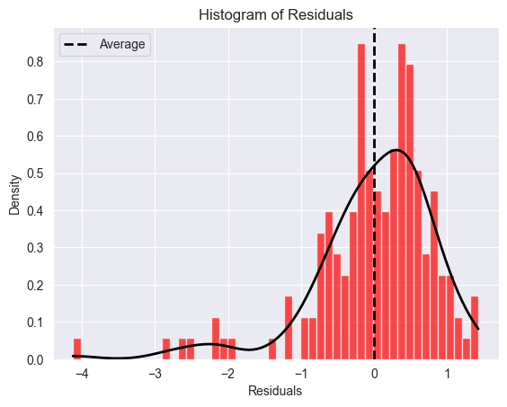

```python
#Histogram of residuals - model_with_interaction_4
hist_residuals(model_with_interaction_4)
```

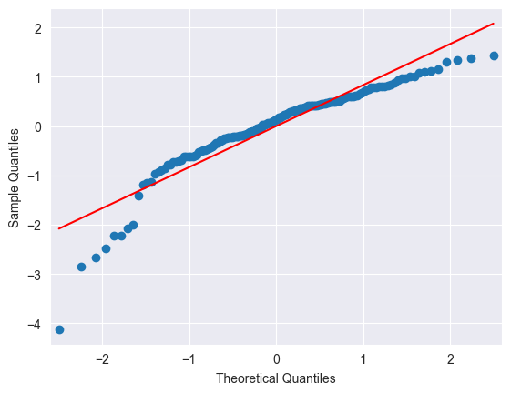

```python
#QQ-plot - model_with_interaction_4
sm.qqplot(model_with_interaction_4.resid, line = 's')
plt.show()
```

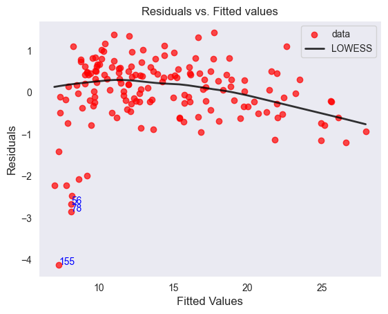

```python
#Scatter plot of residuals vs. fitted values - model_with_interaction_4
residuals_fittedvalues_plot(model_with_interaction_4)
```

```python
#Check Cook's ditance - model_with_interaction_4
influencer_detector(model_with_interaction_4)
```

```
(array([], dtype=int64),)
```

```python
#Check multicollinearity for numeric variables
calc_vif(X_train_interaction_4[['tv', 'radio', 'tv_radio']])
#Note: If VIF > 10 then multicollinearity is high
# Now every metircs are acceptable
```

|  | variables | VIF |
| --- | --- | --- |
| 0 | tv | 3.618993 |
| 1 | radio | 3.930637 |
| 2 | tv_radio | 6.468731 |

```python
# مدل 4 بهترین مدل به دست آمده است.
```

# E

## Model Evaluation

```python
X_test = test[['tv', 'radio', 'newspaper']]
y_test = test['sales']
X_test.head()
```

|  | tv | radio | newspaper |
| --- | --- | --- | --- |
| 50 | 199.8 | 3.1 | 34.6 |
| 127 | 80.2 | 0.0 | 9.2 |
| 37 | 74.7 | 49.4 | 45.7 |
| 149 | 44.7 | 25.8 | 20.6 |
| 19 | 147.3 | 23.9 | 19.1 |

```python
poly_features = PolynomialFeatures(interaction_only=True)
X_test_interaction = pd.DataFrame(poly_features.fit_transform(test[['tv', 'radio', 'newspaper']]),
                                  columns=['const', 'tv', 'radio', 'newspaper', 'tv_radio', 'tv_newspaper',
                                           'radio_newspaper'], index=X_test.index)

X_test_interaction_4 = X_test_interaction[['const', 'tv', 'radio', 'tv_radio']]
X_test_interaction_4.head()
# y_test.head()
```

|  | const | tv | radio | tv_radio |
| --- | --- | --- | --- | --- |
| 50 | 1.0 | 199.8 | 3.1 | 619.38 |
| 127 | 1.0 | 80.2 | 0.0 | 0.00 |
| 37 | 1.0 | 74.7 | 49.4 | 3690.18 |
| 149 | 1.0 | 44.7 | 25.8 | 1153.26 |
| 19 | 1.0 | 147.3 | 23.9 | 3520.47 |

```python
#Prediction using model_with_interaction_4
test_pred = model_with_interaction_4.predict(X_test_interaction_4)
test['pred'] = test_pred
print(test)
```

```
      no     tv  radio  newspaper  sales       pred
50    51  199.8    3.1       34.6   11.4  11.325759
127  128   80.2    0.0        9.2    8.8   8.287944
37    38   74.7   49.4       45.7   14.7  13.866567
149  150   44.7   25.8       20.6   10.1   9.775657
19    20  147.3   23.9       19.1   14.6  14.118851
104  105  238.2   34.3        5.3   20.7  21.071477
179  180  165.6   10.0       17.6   12.6  12.009754
53    54  182.6   46.2       58.7   21.2  20.733993
162  163  188.4   18.1       25.6   14.9  14.569929
158  159   11.7   36.9       45.2    7.3   8.812650
82    83   75.3   20.3       32.5   11.3  10.542746
185  186  205.0   45.1       19.6   22.6  21.960598
182  183   56.2    5.7       29.7    8.7   8.376982
189  190   18.7   12.1       23.4    6.7   7.804419
```

[output cut: 26 more lines]

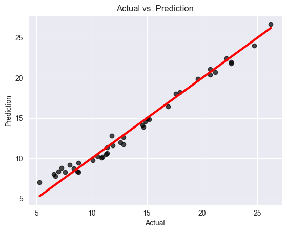

```python
#Actual vs. Prediction
plt.scatter(x=test['sales'], y=test['pred'],
            c='black', alpha=0.7)
plt.xlabel('Actual')
plt.ylabel('Prediction')
plt.title('Actual vs. Prediction')

#Add 45 degree line
xp = np.linspace(test['sales'].min(), test['sales'].max(), 100)
plt.plot(xp, xp, c='red', linewidth=3)
plt.show()
```

```python
#Absolute percentage error
test['abs_pct_err'] = round(abs(test['sales'] - test['pred']) / test['sales'] * 100, 2)
MAE = np.average(abs(test['sales'] - test['pred']))
MAE
```

```
0.6359056448782932
```

```python
#Summary statistics for absolute percentage error
test['abs_pct_err'].describe()
```

```
count    40.000000
mean      6.418500
std       7.011984
min       0.470000
25%       2.215000
50%       3.375000
75%       7.405000
max      32.650000
Name: abs_pct_err, dtype: float64
```

MAPE = 6.42 MAE = 0.636

# --------------------------------------------------------------------------------------------------------------------------------------------

# Q2

```python
from scipy.stats import t

t_statistics = [1.64, 3.01]
degrees_of_freedom = [34, 10]  #  degrees of freedom = sample size - # of parameters
results = []
for t_statistic, df in zip(t_statistics, degrees_of_freedom):
    p_value = t.sf(abs(t_statistic), df) * 2
    results.append({'t-statistic': t_statistic, 'df': df, 'p-value': p_value})
df_results = pd.DataFrame(results)
print(df_results)
```

```
   t-statistic  df   p-value
0         1.64  34  0.110226
1         3.01  10  0.013118
```

```python
# میزان P-value در مدل 36 ماهع بزرگتر از 0.05 است یعنی نمی توانیم فرض صفر که برابر صفر بودن ضریب مربوط به Labor است را حذف کنیم از طرفی میزان R2 مربوط به مدل 12 ماهه بیشتر است و از آنجایی که هر دو یک متغیر مستقل دارند میتوان نتیجه گرفت که دقت مدل 12 ماهع بیشتر از 36 ماهه است. از طرفی مدل 12 ماهه به شرایط عملیاتی ما نزدیک تر است.
# مدل 36 ماهه اتفاقاتی را در نظر میگیر که اتفاقات غیر مترقبه ای نیستند اما میزان این اتفاقات هم مهم است به طوری که در یک سال دو ماه  در سال دیگر یک ماه و سال بعدی صفر ماه اتفاق افتاده که این خودش باعث میشود مدل ما نتواند به خوبی تخمین بزند و نیاز به داده خیلی بیشتری وجود دارد تا بتوان میانگین ماه هایی که از این نوع حوادث اتفاق می افتد را هم تخمین زد.
# در کل میتوان نتیجه گرفت که مدل 12 ماهه بهتر است.
```

#### B

```python
# اگر از 36 ماه استفاده کنیم که نمیتوانیم مدل خوبی بدست بیاوریم و مدل معنی دار نمی شود و چون داده زیادی هم نداریم نمیتوانیم تعداد ماه های با حادثه را تخمین بزنیم که این خود باعث کاهش دقت مدل میشود.
# اگر از مدل 12 ماهه استفاده کنیم حوادث را در نظر نمیگیریم که خود این حوادث بخشی از این صنعت هستند و اتفاق می افتند.
# اگر مدل تمام ماه های عادی را در نظر بگیریم که بدتر است و انگار عواملی که اثر گذار هستند را نادیده گرفتیم.
# بدون اینکه به گذشته نگاه کنیم نمی توانیم برای آینده برنامه بچینیم. "اگر گذشته را نگاه نکنیم اشتباهات گذشته را تکرار میکنیم"
```